# 02_visualize

Andrea Pedot  
18/02/2021

### Bentornati

Recap della scorsa volta

- `ggplot( DATA ) +`
- `geom_point(mapping = aes(x = , y = , size = , color =)) +`
- `geom_smooth() + # negli esercizi a casa`
- `facet_wrap( ~ EQUAZIONE )`

### Obiettivi della serata

- altre geometrie e trasformazioni statistiche completamente automatiche
- posizionamento dei grafici e sistemi di coordinate

Si parte sempre con

```r
library(tidyverse)
```

### Geometrie di base /codice

Le `geom` sono l'oggetto geometrico che il plot usa per rappresentare i dati (i bar chart usano le barre, i grafici a linee le linee, gli scatterplot i punti, …).

Per cambiare le geometrie basta cambiare la funzione `geom` che si aggiunge al `ggplot()`.

Ogni funzione `geom` prende un argomento `mapping =`, ma attenzione che non tutte le estetiche funzionano con tutte le funzioni.

Ad esempio, non esiste `aes( shape = ...)` per una linea creata con `geom_line()`, ma esiste `aes( linetype = ...)`

[figure not shown]

### Geometrie di base /grafici

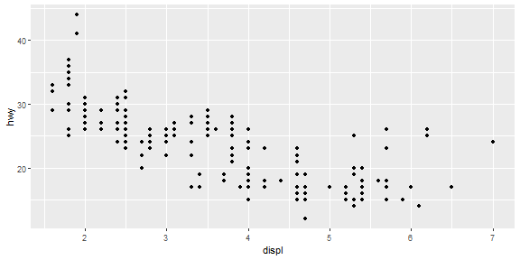

```r
ggplot(data = mpg) +
  geom_point(mapping =
      aes(x=displ, y=hwy) )
```

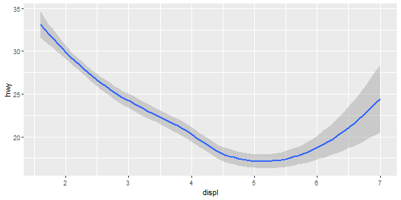

```r
ggplot(data = mpg) +
  geom_smooth(mapping =
      aes(x=displ, y=hwy) )
```

### Combinare geometrie /codice

ggplot2 ha più di 40 geoms, e gli extension packages ne aggiungono molti altri.

Il miglior modo per avere una panoramica generale è usare il cheatsheet di gglplot 2, che si può trovare su http://rstudio.com/resources/cheatsheets.

Come sempre, per approfondire una `geom` si può usare `?geom_smooth`

Tornando al grafico delle slide precedenti, combinare più geometrie su un unico grafico è estremamente semplice

```r
# le aes definite in ggplot() si ereditano in tutte le geom()
ggplot(data = mpg,
       mapping = aes(x = displ,
                     y = hwy,
                     color = drv) ) +
  geom_point() +
# aes definite nella geom rimangono locali
  geom_smooth(mapping = aes(linetype = drv))
```

### Combinare geometrie /grafico

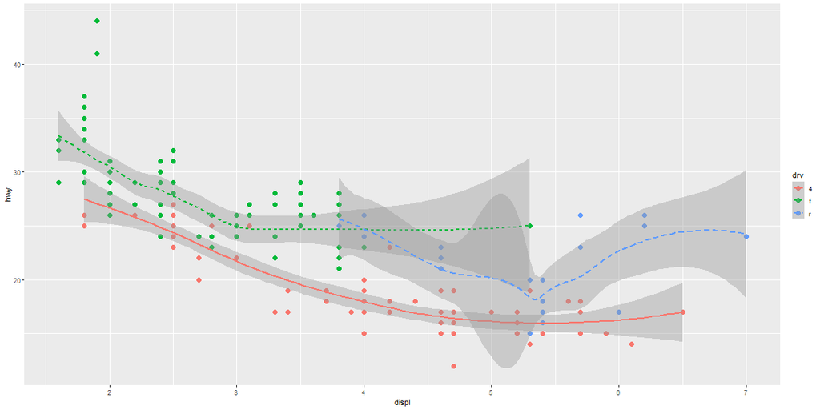

### Geometrie con dati particolari /codice

Il parametro **DATA** in `ggplot(data = ...)` viene anche lui ereditato in tutte le funzioni `geom()` che aggiungiamo, ma possiamo scegliere di specificarlo localmente, semplicemente definendo il parametro `data =` all'interno della funzione `geom()`

```r
ggplot(data = mpg,
       mapping = aes(x = displ,
                     y = hwy) ) +
  geom_point(mapping = aes(color = class)) +
  geom_smooth(data = filter(mpg, class == "subcompact"),
              se = FALSE)
```

Oppure si possono usare filtri in base al valore

```r
geom_smooth(data = # mostra una smooth fatta solo sulle auto
            filter(mpg, cyl >= 6) )    # a grande cilindrata
```

### Geometrie con dati particolari /grafico

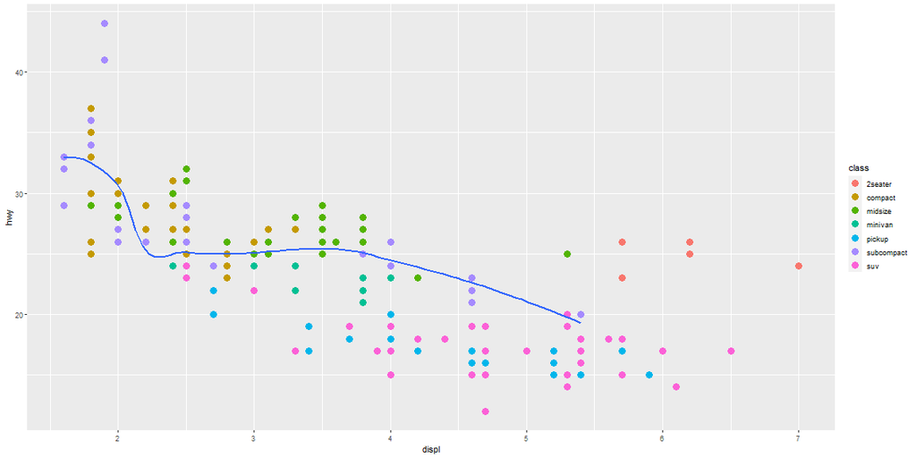

### Esercizi /1

1. Prova a immaginare che grafico produrrà questo codice

```r
ggplot(data = mpg, mapping = aes(x = displ, y = hwy, color = drv)) +
  geom_point() +
  geom_smooth(se = FALSE)
```

1. In cosa saranno diversi questi due grafici?

```r
ggplot(data = mpg, mapping = aes(x = displ, y = hwy)) +
  geom_point() +
  geom_smooth()

ggplot() +
  geom_point(data = mpg, mapping = aes(x = displ, y = hwy)) +
  geom_smooth(data = mpg, mapping = aes(x = displ, y = hwy))
```

### Esercizi /2

1. 1. Quale `geom()` si usa per disegnare un istogramma? Un boxplot? Un grafico ad area? Una heatmap?
2. A cosa serve l'argomento `se = ...` di `geom_smooth()`?
3. Prova a ricreare il codice per questi due grafici

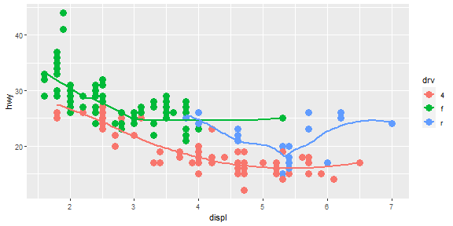

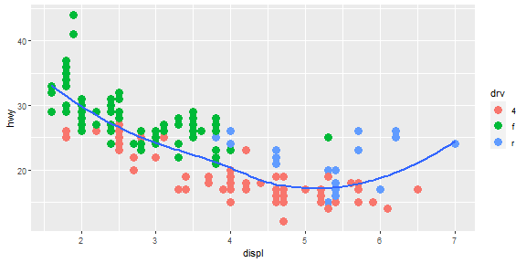

### Trasformare i dati

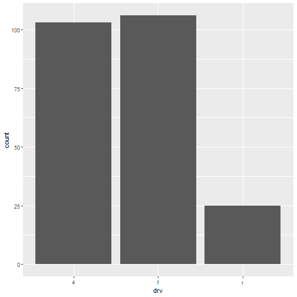

```r
ggplot(data = mpg) +
  geom_bar(mapping =
             aes(x = drv))
```

In questo grafico a barre sull'asse y c'è count, ma non c'è nessuna variabile `count` nel dataset di partenza. Come è possibile?

Alcune `geom_()` ( come anche `geom_boxplot()`, `geom_histogram` e `geom_density()` ) operano delle trasformazioni statistiche sui dati prima del plotting, chiamate `stat`

### Schema in breve

Ogni `geom()` ha una `stat()` di default, e viceversa.

La pagina help di `?geom_bar` è la stessa di `?stat_count()` e alla sezione **Computed variables** si può vedere che calcola due nuove variabili: `count` e `prop`

### Stat = "identity"

`geom_bar( stat = "identity" )` si usa tutte quelle volte che avete già calcolato la statistica riassuntiva e volete fare il grafico “così com'è”.

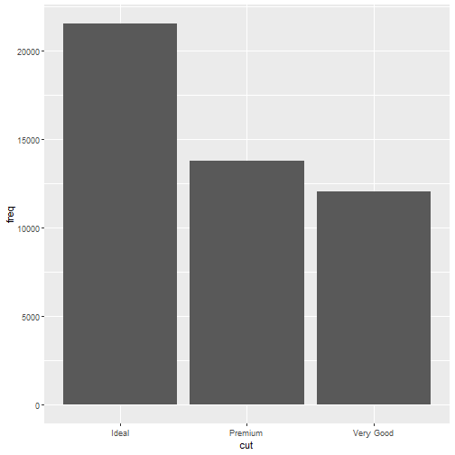

```r
demo <- tribble(
  ~cut,         ~freq,
  "Very Good",  12082,
  "Premium",    13791,
  "Ideal",      21551
)

ggplot(data = demo) +
  geom_bar(mapping =
             aes(x = cut,
             y = freq),
           stat = "identity")
```

`ggplot` vi mette a disposizione anche `geom_col()` che fa esattamente la stessa cosa.

### after_stat() per usare altre *computed variables*

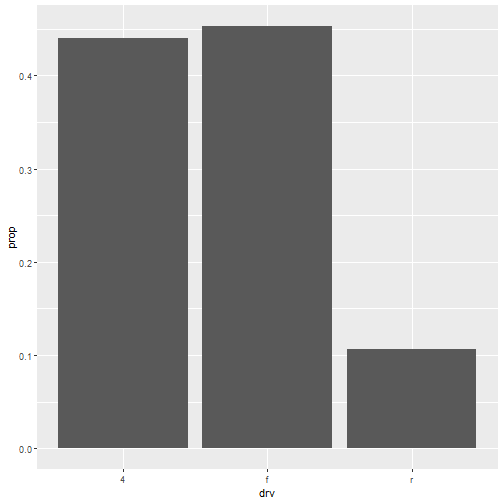

```r
ggplot(data = mpg) +
  geom_bar(mapping = aes(x = drv,
                         y = after_stat(prop),
                         group = 1))
```

### stat_summary()

Ci sono più di 20 `stat_function()` e il codice è estremamente personalizzabile

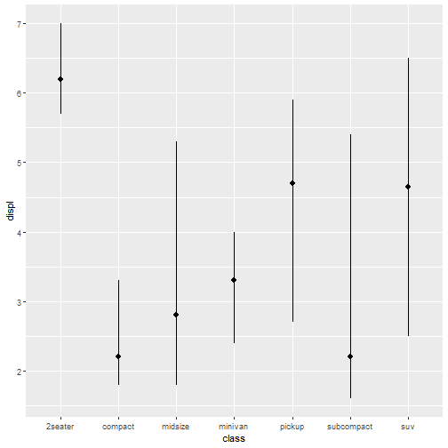

```r
ggplot(data = mpg) +
  stat_summary(
    mapping = aes(x = class,
                  y = displ),
    fun.min = min,
    fun.max = max,
    fun = median
  )
```

### Esercizi /3

1. Qual è la `geom` predefinita associata a `stat_summary()`? Come si può riscrivere il grafico precedente per usare quella funzione geom invece della funzione stat?
2. Quali variabili (**computed variables**) calcola `stat_smooth()`? Quali parametri invece controllano il suo comportamento?
3. Nel nostro grafico a barre delle proporzioni, dobbiamo impostare “group = 1”. Perché? In altre parole, qual è il problema con questi due grafici?

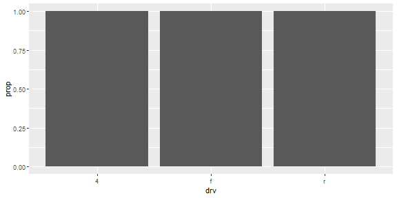

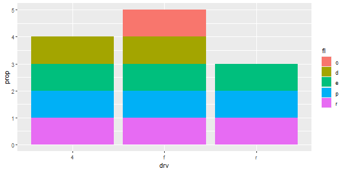

### Un altro blocco: Position

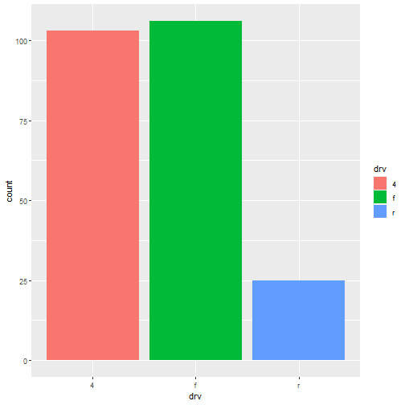

```r
ggplot(data = mpg) +
  geom_bar(mapping =
             aes(x = drv,
                 fill = drv))
```

```r
# fill -> riempimento
# color -> bordi
```

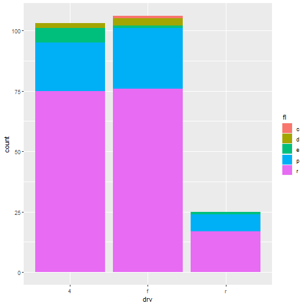

```r
ggplot(data = mpg) +
  geom_bar(mapping =
             aes(x = drv,
                 fill = fl))
```

### Un altro blocco: Position /2

In automatico un attributo diverso all'estetica `fill =` definisce un posizionamento della varie barre “una sopra l'altra”.

In questo caso del `geom_bar()` il valore predefinito è `position = "stack"`, ma ne esistono 5 in tutto:

- `position = "identity"` per le sovrapposizioni (accoppiato ad `alpha =` tra 0 e 1 per vedere in trasparenza)
- `position = "dodge"` per l'affiancamento
- `position = "jitter"` per lo sparpagliamento
- `position = "fill"` per il riempimento in proporzione
- `geom_label(position = "nudge")` per evitare che le etichette si sovrappongano

### Esempi di posizionamenti /1

```r
  position = "dodge"
```

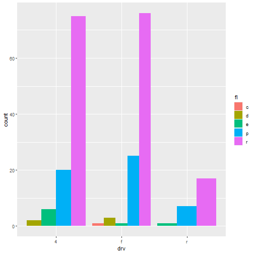

```r
  position = "identity",
  alpha = 0.33
```

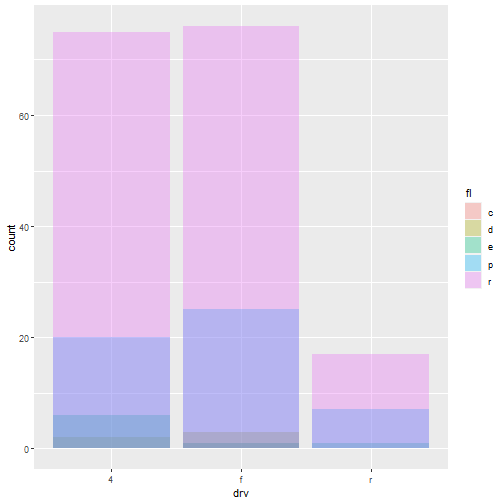

### Esempi di posizionamenti /2

```r
  position = "fill"
```

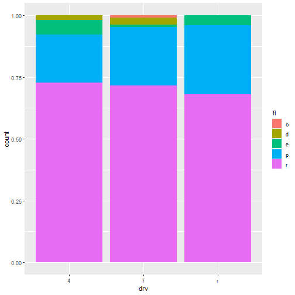

```r
  position = "jitter"
```

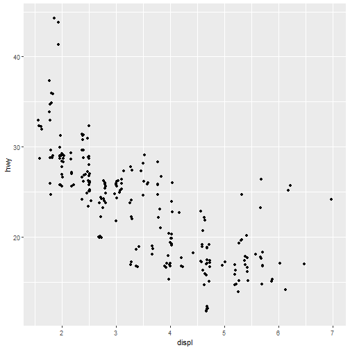

### Esercizi /4

1. Qual è il problema con il grafico a destra? Come si può migliorare?
2. Come si calcola la quantità di jittering?
3. Comparando `geom_jitter()` e `geom_count()`, quando è più utile l'uno? Quando è più utile l'altro?
4. Qual è la position di default di `geom_boxplot()`?

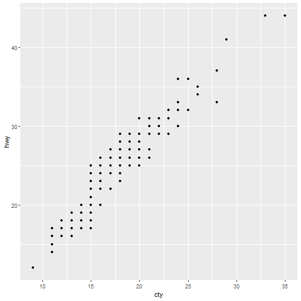

```r
ggplot(data = mpg,
       mapping =
         aes(x = cty,
         y = hwy) ) +
  geom_point()
```

### Sistemi di coordinate /1

`coord_flip()` per ribaltare il grafico e renderlo più leggibile

`coord_fixed()` per renderlo quadrato

### Sistemi di coordinate /2

`coord_polar( theta = "y" )` per renderlo polare (theta = “y” per renderlo un grafico a torta)